# HW4

2022-11-04

#1

## a

```r
missing_value_in_bill_length =  sum(is.na(penguins$bill_length_mm)) / length(penguins$bill_length_mm) * 100
missing_value_in_bill_depth =  sum(is.na(penguins$bill_depth_mm)) / length(penguins$bill_depth_mm) * 100
missing_value_in_sex = sum (is.na(penguins$sex)) / length(penguins$sex)  * 100

cat("percentage of missing bill length mm is",missing_value_in_bill_length, "\n")
```

```
## percentage of missing bill length mm is 0.5813953
```

```r
cat("percentage of missing bill depth in mm is",missing_value_in_bill_depth, "\n")
```

```
## percentage of missing bill depth in mm is 0.5813953
```

```r
cat("percentage of missing sex is", missing_value_in_sex, "\n")
```

```
## percentage of missing sex is 3.197674
```

## b

```r
remove_na_penguin <- na.omit(penguins)
male <- remove_na_penguin[remove_na_penguin$sex == 'male', ]
female <- remove_na_penguin[remove_na_penguin$sex == 'female', ]

mean_male_body_mass <- mean(male$body_mass_g)
mean_female_body_mass <- mean(female$body_mass_g)

median_male_body_mass <- median(male$body_mass_g)
median_female_body_mass <- median(female$body_mass_g)

cat("mean of the body mass for male penguins is",mean_male_body_mass, "\n")
```

```
## mean of the body mass for male penguins is 4545.685
```

```r
cat("mean of the body mass for female penguins is",mean_female_body_mass, "\n")
```

```
## mean of the body mass for female penguins is 3862.273
```

```r
cat("median of the body mass for male penguins is", median_male_body_mass, "\n")
```

```
## median of the body mass for male penguins is 4300
```

```r
cat("median of the body mass for female penuins is", median_female_body_mass, "\n")
```

```
## median of the body mass for female penuins is 3650
```

## c

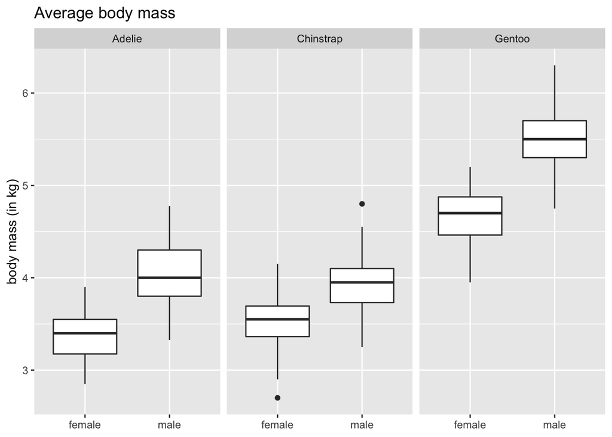

```r
remove_na_penguin$body_mass_g = remove_na_penguin$body_mass_g /1000
  ggplot(data = remove_na_penguin, mapping = aes(x = factor(sex), y = body_mass_g)) +
  geom_boxplot() +
  facet_grid(~species) +
  labs ( x = NULL,
         y = "body mass (in kg)",
         title = "Average body mass")
```

I found that male penguin is heavier than female penguin. I also noticed Gentoo species overall is much heavier than those of Adelie and Chinstrap.

## d

```r
G = remove_na_penguin %>% group_by(year, species, sex) %>%
  summarise(average = mean(body_mass_g))
```

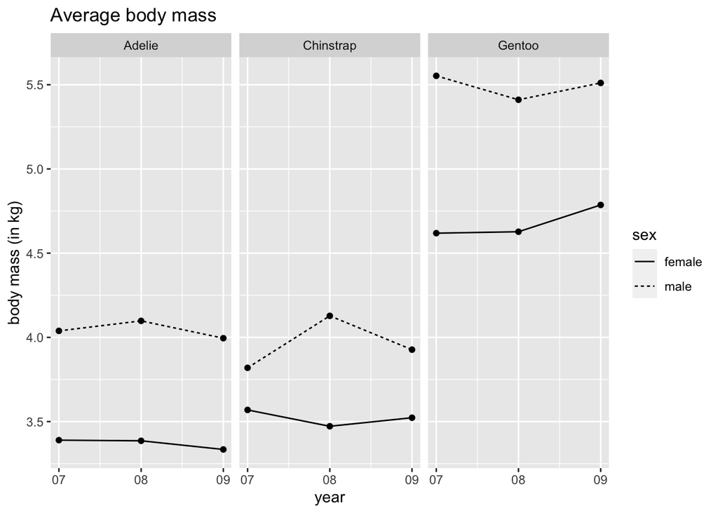

```r
ggplot(data = G, mapping = aes(x = year, y = average)) +
  # make the point
  geom_point() +
  # make line for each sex
  geom_line(aes(linetype = sex)) +
  # separate each spcices
  facet_grid(~species) +
  labs (x = "year",
        y = "body mass (in kg)",
        title = "Average body mass") +
  scale_x_continuous(breaks = seq(2007, 2009 , by = 1),
                     label = c("2007" = "07",
                               "2008" = "08",
                               "2009" = "09"))
```

I found that male overall has heavier body mass than female, and gentoo is heavier than other two species.

## e

```r
G1 = remove_na_penguin %>% group_by(year, species, sex, flipper_length_mm) %>%
  summarise(average = mean(body_mass_g))
```

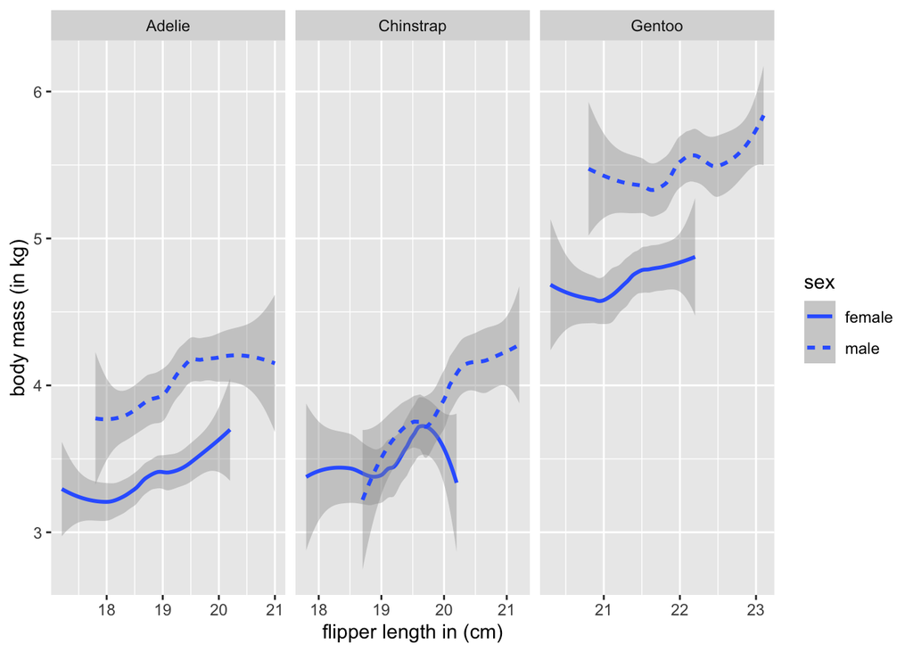

```r
ggplot(data = G1, mapping = aes(x = flipper_length_mm /10, y = average, group = sex)) +
  # make line for each sex
  # separate each spcices
  facet_grid(~species, scales = "free_x") +
  labs (x = "flipper length in (cm)",
        y = "body mass (in kg)") +
  geom_smooth(aes(linetype = sex))
```

I found that as flipper length in cm increases, teh body mass in kg increases as well. Male has a bigger trend of gaining body mass than female does.

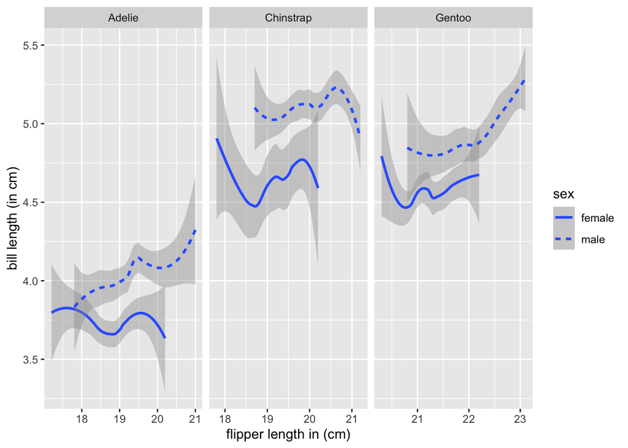

```r
ggplot(data = remove_na_penguin, mapping = aes(x = flipper_length_mm/10, y = bill_length_mm/ 10)) +
  geom_smooth(aes(linetype=sex)) +
  facet_grid(~species, scales = "free_x") +
  labs (x = "flipper length in (cm)",
        y = "bill length (in cm)")
```

I found that Gentoo overall has a very high potential of having more bill length as fliper length length increases as I observe from the graph.

#2

##a

```r
flights %>%
  group_by(dest) %>%
  summarise(count = n()) %>%
  arrange(desc(count))
```

```
## # A tibble: 105 × 2
##    dest  count
##    <chr> <int>
##  1 ORD   17283
##  2 ATL   17215
##  3 LAX   16174
##  4 BOS   15508
##  5 MCO   14082
##  6 CLT   14064
##  7 SFO   13331
##  8 FLL   12055
##  9 MIA   11728
## 10 DCA    9705
## # … with 95 more rows
```

The most frequent destination airports for all flights departing from New York City is “ORD”

##b

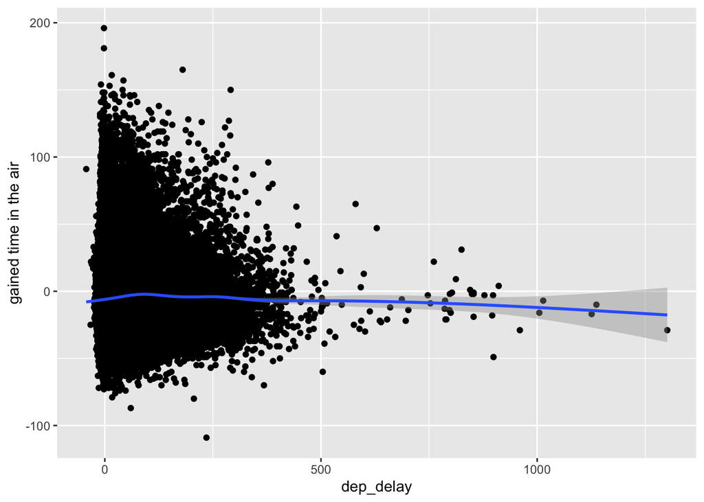

```r
# calculated the "gained time in the air"
f <- flights %>%
  mutate("gained_time_in_th_air" = (arr_delay-dep_delay))

f <- na.omit(f)

ggplot (f, aes(x =dep_delay, y =gained_time_in_th_air  )) + geom_point() +
  labs(x = "dep_delay",
       y = "gained time in the air") +
  geom_smooth()
```

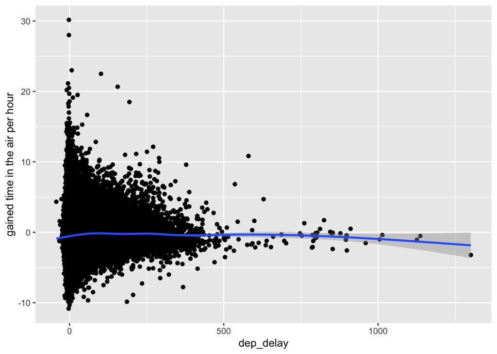

```r
# calculated the "gained time in the air per hour"

ggplot (f, aes(x =dep_delay, y=gained_time_in_th_air/hour)) + geom_point() +
  labs(x = "dep_delay",
       y = "gained time in the air per hour") +
  geom_smooth()
```

##c

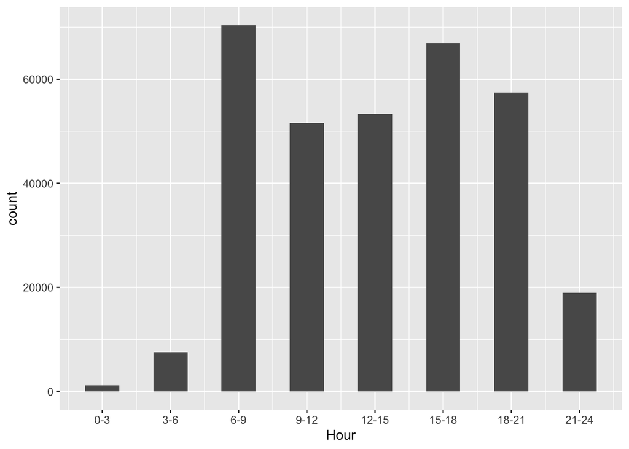

```r
# 1. removed cancelled flights
# meaning the flights do not have arrival time or departure time
f <- na.omit(flights)

# 2. create a variable which equals 0 if the flight took off between 0 and 3 am, equals 1 if took off between 3 and 6 am…

f <- f %>% mutate(took_off = (dep_time %/% 100) )


variable <- case_when(f$took_off >=0 & f$took_off < 3 ~ 0,
                      f$took_off >=3 & f$took_off < 6 ~ 1,
                      f$took_off >=6 & f$took_off < 9 ~ 2,
                      f$took_off >=9 & f$took_off < 12 ~ 3,
                      f$took_off >=12 & f$took_off < 15 ~ 4,
                      f$took_off >=15 & f$took_off < 18 ~ 5,
                      f$took_off >=18 & f$took_off < 21 ~ 6,
                      f$took_off >=21 & f$took_off < 24 ~ 7)

df <- unlist(variable, use.names = FALSE)



ggplot() + geom_histogram(aes(df), bins = 30, binwidth = 0.5) +
  labs(x = "Hour",
      y = "count") +
  scale_x_continuous(breaks = seq(0, 7 , by = 1),
                     label = c (
                '0' = "0-3", '1' = "3-6",'2' = "6-9",'3' = "9-12",
                '4' = "12-15", '5' = "15-18",'6' = "18-21",'7' = "21-24"))
```

#3

## a

```r
filter(babynames, year == 2010 & n < 10000) %>%
  select(name)
```

```
## # A tibble: 34,020 × 1
##    name
##    <chr>
##  1 Ella
##  2 Natalie
##  3 Samantha
##  4 Alexis
##  5 Lily
##  6 Grace
##  7 Hailey
##  8 Alyssa
##  9 Hannah
## 10 Lillian
## # … with 34,010 more rows
```

This is the optional

```r
babynames %>%
  group_by(year, sex,n) %>%
  select (year, sex, name, n) %>%
  filter(n < 10000)
```

```
## # A tibble: 1,918,820 × 4
## # Groups:   year, sex, n [160,383]
##     year sex   name          n
##    <dbl> <chr> <chr>     <int>
##  1  1880 F     Mary       7065
##  2  1880 F     Anna       2604
##  3  1880 F     Emma       2003
##  4  1880 F     Elizabeth  1939
##  5  1880 F     Minnie     1746
##  6  1880 F     Margaret   1578
##  7  1880 F     Ida        1472
##  8  1880 F     Alice      1414
##  9  1880 F     Bertha     1320
## 10  1880 F     Sarah      1288
## # … with 1,918,810 more rows
```

```r
# 1918 820
```

## b

```r
babynames %>%
  filter(year == 2010) %>%
  # in case there is duplicate
  group_by(name) %>%
  mutate(name_length = str_length(name)) %>%
  # sort from longest to shorest
  arrange(desc(name_length))
```

```
## # A tibble: 34,067 × 6
## # Groups:   name [31,623]
##     year sex   name                n       prop name_length
##    <dbl> <chr> <chr>           <int>      <dbl>       <int>
##  1  2010 M     Christianjoseph     7 0.00000341          15
##  2  2010 M     Christopherjame     5 0.00000244          15
##  3  2010 M     Jaydenalexander     5 0.00000244          15
##  4  2010 F     Mariaguadalupe     16 0.00000817          14
##  5  2010 F     Mariadelcarmen     10 0.00000511          14
##  6  2010 F     Sarahelizabeth      9 0.0000046           14
##  7  2010 M     Michaelanthony     15 0.00000731          14
##  8  2010 M     Alexanderjames      8 0.0000039           14
##  9  2010 M     Christianjames      7 0.00000341          14
## 10  2010 M     Oluwatimilehin      7 0.00000341          14
## # … with 34,057 more rows
```

## c

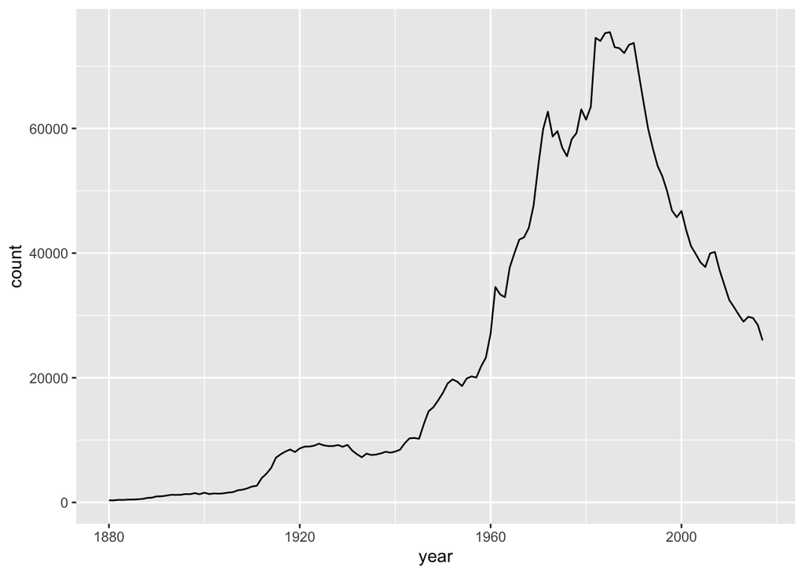

```r
baby_with_long_name <-
  babynames %>%
  # group by name first
  group_by(name) %>%
  # store the length of the name
  mutate(name_length = str_length(name)) %>%
  # only get the length of name that is greater than 10
  filter(name_length >= 10) %>%
  # group by year later
  group_by(year) %>%
  # sum up all the babynames
  summarize(count = sum(n, na.rm = TRUE))

ggplot(data = baby_with_long_name, mapping =
         aes (x = year, y = count)) +
  geom_line()
```

I found that the the length of the babynames started increasing since 1880, then it hit its peak at around 1980’s. But after that, the length of the babynames started decreasing. One of my thoughts is it might be modern people perfer having shorter babynames, so they could save the time of memorizing the name of their kids. Simplistics is the key.

## d (optional)

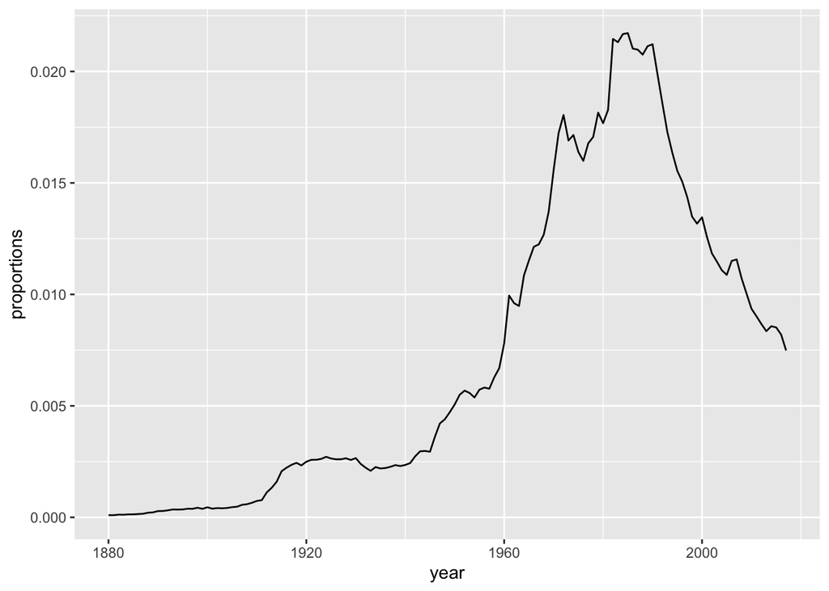

```r
# number of long name babies / total number of babies

baby_with_long_name_prop <-
  baby_with_long_name %>%
  mutate(proportions = count / sum (count, na.rm = TRUE))

ggplot(data = baby_with_long_name_prop, mapping =
         aes (x = year, y = proportions)) +
  geom_line()
```

#4

## a

```r
toy <- tibble(
  x = c(4, 2, 2, 3, 3, 1, 3, 4, 5),
  group = c("c", "b", "a", "c", "b", "a", "a", "b", "c")
)
```

```r
toy %>%
  group_by(group) %>%
  arrange(x)
```

```
## # A tibble: 9 × 2
## # Groups:   group [3]
##       x group
##   <dbl> <chr>
## 1     1 a
## 2     2 b
## 3     2 a
## 4     3 c
## 5     3 b
## 6     3 a
## 7     4 c
## 8     4 b
## 9     5 c
```

No, the code does not work. But the follwing code works.

```r
toy %>%
  group_by(x, group) %>%
  arrange(group,x)
```

```
## # A tibble: 9 × 2
## # Groups:   x, group [9]
##       x group
##   <dbl> <chr>
## 1     1 a
## 2     2 a
## 3     3 a
## 4     2 b
## 5     3 b
## 6     4 b
## 7     3 c
## 8     4 c
## 9     5 c
```

## b

```r
babynames %>%
  filter (year >= 2010 & year <=2017 ) %>%
  group_by(year) %>%
  mutate(rank = rank(-n)) %>%
  arrange(rank)
```

```
## # A tibble: 266,745 × 6
## # Groups:   year [8]
##     year sex   name         n   prop  rank
##    <dbl> <chr> <chr>    <int>  <dbl> <dbl>
##  1  2010 F     Isabella 22905 0.0117     1
##  2  2011 F     Sophia   21837 0.0113     1
##  3  2012 F     Sophia   22304 0.0115     1
##  4  2013 F     Sophia   21213 0.0110     1
##  5  2014 F     Emma     20924 0.0107     1
##  6  2015 F     Emma     20435 0.0105     1
##  7  2016 F     Emma     19471 0.0101     1
##  8  2017 F     Emma     19738 0.0105     1
##  9  2010 M     Jacob    22117 0.0108     2
## 10  2011 M     Jacob    20365 0.0100     2
## # … with 266,735 more rows
```

The top two most popular names: 2010: Isabella, Jacob 2011: Sophia, Jacob 2012: Sophia, Emma 2013: Sophia, Emma 2014: Emma, Olivia 2015: Emma, Olivia 2016: Emma, Olivia 2017: Emma, Liam